# Generating Monet-Style Images Using GANs

## Description of the Problem

Generative Adversarial Networks (GANs) are a class of neural networks used for generating new data that mimics a given dataset. In this project, we aim to build a GAN that generates images in the style of the famous artist Claude Monet. The goal is to generate between 7,000 to 10,000 Monet-style images.

The GAN consists of two neural networks: • Generator: Creates new images that resemble the Monet-style paintings. • Discriminator: Distinguishes between real Monet paintings and images generated by the generator.

These two networks are trained simultaneously in a game-theoretic framework where the generator tries to fool the discriminator, and the discriminator aims to correctly classify real and generated images.

## Importing Libraries

```python
import numpy as np
import pandas as pd
import matplotlib.pyplot as plt
import os
from glob import glob
import tensorflow as tf
from tensorflow.keras.layers import *
from tensorflow.keras.models import Model
from tensorflow.keras.optimizers import Adam
from tensorflow.keras.preprocessing.image import load_img, img_to_array
```

```python
from tensorflow.python.client import device_lib

def get_available_devices():
    local_device_protos = device_lib.list_local_devices()
    return [x.name for x in local_device_protos]

print(get_available_devices())
```

```
['/device:CPU:0', '/device:GPU:0']
```

## Loading and Preprocessing the Data

```python
# Set the path to the dataset
monet_path = 'monet_jpg/'
photo_path = 'photo_jpg/'

# Get the list of image file paths
monet_images = glob(os.path.join(monet_path, '*.jpg'))
photo_images = glob(os.path.join(photo_path, '*.jpg'))

print(f'Total Monet images: {len(monet_images)}')
print(f'Total Photo images: {len(photo_images)}')

# Function to load and preprocess images
def load_and_preprocess_image(image_path, img_size=(256, 256)):
    img = load_img(image_path, target_size=img_size)
    img = img_to_array(img)
    img = (img - 127.5) / 127.5  # Normalize to [-1, 1]
    return img

# Load images into numpy arrays
monet_data = np.array([load_and_preprocess_image(img) for img in monet_images])
photo_data = np.array([load_and_preprocess_image(img) for img in photo_images])

print(f'Monet data shape: {monet_data.shape}')
print(f'Photo data shape: {photo_data.shape}')
```

```
Total Monet images: 300
Total Photo images: 7038
Monet data shape: (300, 256, 256, 3)
Photo data shape: (7038, 256, 256, 3)
```

## Exploratory Data Analysis (EDA)

Let’s visualize some samples from both datasets.

[figure not shown]

[figure not shown]

```python
# Function to display images
def display_samples(data, title, n=5):
    plt.figure(figsize=(20, 4))
    plt.suptitle(title, fontsize=20)
    for i in range(n):
        plt.subplot(1, n, i+1)
        plt.imshow((data[i] * 0.5 + 0.5))
        plt.axis('off')
    plt.show()

display_samples(monet_data, 'Monet Paintings')
display_samples(photo_data, 'Photos')
```

## Observations:

```
•	The Monet paintings have distinctive brush strokes and color palettes.
•	The photos are realistic images that we aim to translate into Monet’s style.
```

## Generator Model

```python
def build_generator():
    inputs = Input(shape=(256, 256, 3))

    # Downsampling layers
    x = Conv2D(64, kernel_size=4, strides=2, padding='same')(inputs)
    x = LeakyReLU(alpha=0.2)(x)
    # Add more layers as needed...

    # Upsampling layers
    x = Conv2DTranspose(64, kernel_size=4, strides=2, padding='same')(x)
    x = Activation('tanh')(x)
    # Add more layers as needed...

    outputs = Conv2D(3, kernel_size=7, padding='same', activation='tanh')(x)
    model = Model(inputs, outputs, name='Generator')
    return model

generator = build_generator()
generator.summary()
```

[output not shown]

## Discriminator Model

```python
def build_discriminator():
    inputs = Input(shape=(256, 256, 3))

    x = Conv2D(64, kernel_size=4, strides=2, padding='same')(inputs)
    x = LeakyReLU(alpha=0.2)(x)
    # Add more layers as needed...

    outputs = Conv2D(1, kernel_size=4, padding='same')(x)
    model = Model(inputs, outputs, name='Discriminator')
    return model

discriminator = build_discriminator()
discriminator.summary()
```

[output not shown]

## Compiling the Models

```python
# Optimizers
opt = Adam(learning_rate=0.0002, beta_1=0.5)

# Compile Discriminator
discriminator.compile(loss='mse', optimizer=opt, loss_weights=[0.5])

# Build and compile the combined model
def build_gan(generator, discriminator):
    discriminator.trainable = False
    gan_input = Input(shape=(256, 256, 3))
    generated_image = generator(gan_input)
    gan_output = discriminator(generated_image)
    gan = Model(gan_input, gan_output)
    gan.compile(loss='mse', optimizer=opt)
    return gan

gan = build_gan(generator, discriminator)
gan.summary()
```

[output not shown]

## Training the GAN

```python
import datetime

def train_gan(generator, discriminator, epochs, batch_size):
    # Ensure models are trainable
    generator.trainable = True
    discriminator.trainable = True

    # Create optimizers
    generator_optimizer = tf.keras.optimizers.Adam(learning_rate=0.0002, beta_1=0.5)
    discriminator_optimizer = tf.keras.optimizers.Adam(learning_rate=0.0002, beta_1=0.5)

    # Loss function
    cross_entropy = tf.keras.losses.BinaryCrossentropy(from_logits=False)

    def train_step(real_images, images):
        with tf.GradientTape() as gen_tape, tf.GradientTape() as disc_tape:
            # Generate fake images
            generated_images = generator(images, training=True)

            # Discriminator output
            real_output = discriminator(real_images, training=True)
            fake_output = discriminator(generated_images, training=True)

            # Calculate losses
            d_loss_real = cross_entropy(tf.ones_like(real_output), real_output)
            d_loss_fake = cross_entropy(tf.zeros_like(fake_output), fake_output)
            d_loss = (d_loss_real + d_loss_fake) * 0.5

            g_loss = cross_entropy(tf.ones_like(fake_output), fake_output)

        # Calculate gradients
        gradients_of_generator = gen_tape.gradient(g_loss, generator.trainable_variables)
        gradients_of_discriminator = disc_tape.gradient(d_loss, discriminator.trainable_variables)

        # Check for None gradients
        if any(grad is None for grad in gradients_of_generator):
            print("Warning: Some generator gradients are None")
        if any(grad is None for grad in gradients_of_discriminator):
            print("Warning: Some discriminator gradients are None")

        # Apply gradients
        generator_optimizer.apply_gradients(zip(gradients_of_generator, generator.trainable_variables))
        discriminator_optimizer.apply_gradients(zip(gradients_of_discriminator, discriminator.trainable_variables))

        return d_loss, g_loss

    # Training loop
    for epoch in range(epochs):
        d_losses = []
        g_losses = []
        num_batches = len(photo_data) // batch_size
        for batch_i in range(num_batches):
            # Get batch data
            idx_monet = np.random.randint(0, monet_data.shape[0], batch_size)
            real_images = monet_data[idx_monet]
            real_images = tf.convert_to_tensor(real_images, dtype=tf.float32)

            idx_photo = np.random.randint(0, photo_data.shape[0], batch_size)
            images = photo_data[idx_photo]
            images = tf.convert_to_tensor(images, dtype=tf.float32)

            # Train step
            d_loss, g_loss = train_step(real_images, images)
            d_losses.append(d_loss)
            g_losses.append(g_loss)

        # Epoch summary
        d_loss_avg = tf.reduce_mean(d_losses)
        g_loss_avg = tf.reduce_mean(g_losses)
        print(f"Epoch {epoch+1}/{epochs} completed. [D loss: {d_loss_avg:.4f}] [G loss: {g_loss_avg:.4f}]")
```

### Start Training

```python
epochs = 50
batch_size = 16
train_gan(generator, discriminator, epochs, batch_size)
```

[output not shown]

## Generating Monet-Style Images

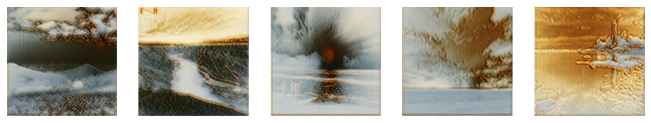

```python
def generate_images(generator, test_input):
    prediction = generator.predict(test_input)
    plt.figure(figsize=(12, 12))

    for i in range(len(prediction)):
        plt.subplot(1, len(prediction), i+1)
        plt.imshow((prediction[i] * 0.5 + 0.5))
        plt.axis('off')
    plt.show()

# Select a few photos to translate
test_photos = photo_data[:5]
generate_images(generator, test_photos)
```

## Saving Generated Images

```python
import cv2

output_path = 'generated_images/'
os.makedirs(output_path, exist_ok=True)

for i in range(len(photo_data)):
    img = np.expand_dims(photo_data[i], axis=0)
    gen_img = generator.predict(img)
    gen_img = (gen_img[0] * 127.5 + 127.5).astype(np.uint8)
    cv2.imwrite(os.path.join(output_path, f'monet_{i}.jpg'), cv2.cvtColor(gen_img, cv2.COLOR_RGB2BGR))

print(f"Generated images saved to {output_path}")
```

```
Generated images saved to generated_images/
```

## Discussion and Conclusion

### Challenges:

```
•	Training Stability: GANs can be difficult to train due to the delicate balance between the generator and discriminator.
•	Data Size: The quality of generated images can improve with more training data and longer training times.
```

## Future Work:

```
•	Model Refinement: Experiment with different architectures and hyperparameters to improve the quality of the generated images.
•	Evaluation Metrics: Implement metrics like the Fréchet Inception Distance (FID) to quantitatively assess the quality of generated images.
```

## References

```
•	Goodfellow, I. et al. (2014). Generative Adversarial Nets.
•	Zhu, J. et al. (2017). Unpaired Image-to-Image Translation using Cycle-Consistent Adversarial Networks.
```